# 09

#### Scipy:

We have the min and max temperatures in a city In India for each months of the year. We would like to find a function to describe this and show it graphically, the dataset given below.

#### Task:

- fitting it to the periodic function
- plot the fit

  Data
  - Max = 39, 41, 43, 47, 49, 51, 45, 38, 37, 29, 27, 25
  - Min = 21, 23, 27, 28, 32, 35, 31, 28, 21, 19, 17, 18

#### Expected Output:

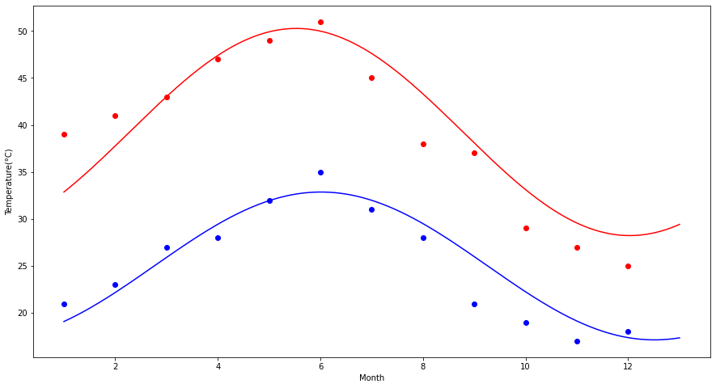

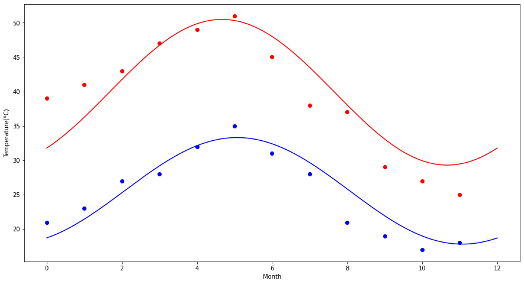

```python
import numpy as np
import matplotlib.pyplot as plt
from scipy import optimize

thermax = np.array([39, 41, 43, 47, 49, 51, 45, 38, 37, 29, 27, 25])
thermin = np.array([21, 23, 27, 28, 32, 35, 31, 28, 21, 19, 17, 18])
month = np.arange(0,12)

# Pseudo Data Points
days = np.linspace(0,12, num = 365) # Dummy timeframe for curve fitting

def model(times, avg, amp, time_offset):
    omega = 2 * np.pi / times.max()
    return (avg + amp * np.cos(omega * (times + time_offset)))

res_max, cov_max = optimize.curve_fit(model, month, thermax, p0=[38, 13, 1])
res_min, cov_min = optimize.curve_fit(model, month, thermin, p0=[26, 9, 1])

plt.figure(figsize = (15,8))
plt.plot(month, thermax, 'ro') # Scatter-plot of data points for maximum temperature
plt.plot(days, model(days, * res_max), 'r-') # Fitting the non-linear curve using the model for maximum temperature
plt.plot(month, thermin, 'bo') # Scatter-plot of data points for minimum temperature
plt.plot(days, model(days, * res_min), 'b-') # Fitting the non-linear curve using the model for minimum temperature
plt.xlabel('Month')
plt.ylabel('Temperature(\u00B0C)')
```

### [Using trigonometric functions to model climate](https://niwa.co.nz/education-and-training/schools/resources/climate/modelling)

An equation that can be used to model these data is of the form: $$y = A cos B(x - C) + D$$

> where $A,B,C,D$ are constants, $y$ is the temperature in $°C$ and $x$ is the month (1–12).
> - $A$ = amplitude = $(ymax - ymin) / 2$
> - $B$ = $2π/12$
> - $C$ = units translated to the right
> - $D$ = $ymin + amplitude$ = units translated up

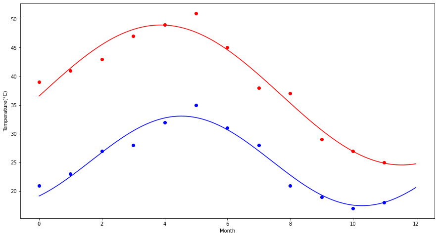

```python
import numpy as np
import matplotlib.pyplot as plt
from scipy import optimize

thermax = np.array([39, 41, 43, 47, 49, 51, 45, 38, 37, 29, 27, 25])
thermin = np.array([21, 23, 27, 28, 32, 35, 31, 28, 21, 19, 17, 18])
month = np.arange(0,12)

# Pseudo Data Points
days = np.linspace(0,12, num = 365) # Dummy timeframe for curve fitting

def model(times, A, B, C, D):

    return (A * np.cos(B * (times -C)) +D)

res_max, cov_max = optimize.curve_fit(model, month, thermax, p0=[13, 0.5, 1, 38], absolute_sigma=True)
res_min, cov_min = optimize.curve_fit(model, month, thermin,  p0=[9, 0.5, 1, 26], absolute_sigma=True)

plt.figure(figsize = (15,8))
plt.plot(month, thermax, 'ro') # Scatter-plot of data points for maximum temperature
plt.plot(days, model(days, * res_max), 'r-') # Fitting the non-linear curve using the model for maximum temperature
plt.plot(month, thermin, 'bo') # Scatter-plot of data points for minimum temperature
plt.plot(days, model(days, * res_min), 'b-') # Fitting the non-linear curve using the model for minimum temperature
plt.xlabel('Month')
plt.ylabel('Temperature(\u00B0C)')
```

#### Visualization using matplotlib:

Data:

- url=https://raw.githubusercontent.com/Geoyi/Cleaning-Titanic-Data/master/titanic_original.csv
- titanic = pd.read_csv(url) #### Charts to plot:
  1. Create a pie chart presenting the male/female proportion
  2. Create a scatterplot with the Fare paid and the Age, differ the plot color by gender

```python
import pandas as pd
import matplotlib.pyplot as plt
%matplotlib inline


url= 'https://raw.githubusercontent.com/Geoyi/Cleaning-Titanic-Data/master/titanic_original.csv'
titanic = pd.read_csv(url)
titanic
```

|  | pclass | survived | name | sex | age | sibsp | parch | ticket | fare | cabin | embarked | boat | body | home.dest |
| --- | --- | --- | --- | --- | --- | --- | --- | --- | --- | --- | --- | --- | --- | --- |
| 0 | 1.0 | 1.0 | Allen, Miss. Elisabeth Walton | female | 29.0000 | 0.0 | 0.0 | 24160 | 211.3375 | B5 | S | 2 | NaN | St Louis, MO |
| 1 | 1.0 | 1.0 | Allison, Master. Hudson Trevor | male | 0.9167 | 1.0 | 2.0 | 113781 | 151.5500 | C22 C26 | S | 11 | NaN | Montreal, PQ / Chesterville, ON |
| 2 | 1.0 | 0.0 | Allison, Miss. Helen Loraine | female | 2.0000 | 1.0 | 2.0 | 113781 | 151.5500 | C22 C26 | S | NaN | NaN | Montreal, PQ / Chesterville, ON |
| 3 | 1.0 | 0.0 | Allison, Mr. Hudson Joshua Creighton | male | 30.0000 | 1.0 | 2.0 | 113781 | 151.5500 | C22 C26 | S | NaN | 135.0 | Montreal, PQ / Chesterville, ON |
| 4 | 1.0 | 0.0 | Allison, Mrs. Hudson J C (Bessie Waldo Daniels) | female | 25.0000 | 1.0 | 2.0 | 113781 | 151.5500 | C22 C26 | S | NaN | NaN | Montreal, PQ / Chesterville, ON |
| ... | ... | ... | ... | ... | ... | ... | ... | ... | ... | ... | ... | ... | ... | ... |
| 1305 | 3.0 | 0.0 | Zabour, Miss. Thamine | female | NaN | 1.0 | 0.0 | 2665 | 14.4542 | NaN | C | NaN | NaN | NaN |
| 1306 | 3.0 | 0.0 | Zakarian, Mr. Mapriededer | male | 26.5000 | 0.0 | 0.0 | 2656 | 7.2250 | NaN | C | NaN | 304.0 | NaN |
| 1307 | 3.0 | 0.0 | Zakarian, Mr. Ortin | male | 27.0000 | 0.0 | 0.0 | 2670 | 7.2250 | NaN | C | NaN | NaN | NaN |
| 1308 | 3.0 | 0.0 | Zimmerman, Mr. Leo | male | 29.0000 | 0.0 | 0.0 | 315082 | 7.8750 | NaN | S | NaN | NaN | NaN |
| 1309 | NaN | NaN | NaN | NaN | NaN | NaN | NaN | NaN | NaN | NaN | NaN | NaN | NaN | NaN |

1310 rows × 14 columns